# act_report

## WeRateDogs Report

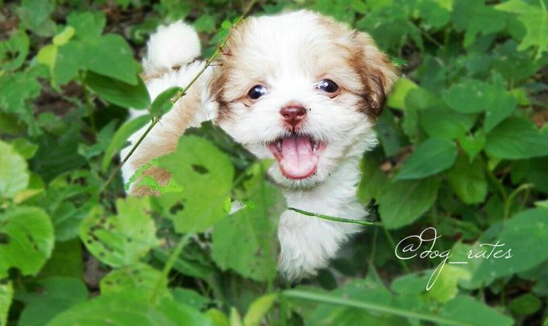

> WeRateDogs is a Twitter account that rates people's dogs with a humorous comment about the dog. These ratings typically have a denominator of 10, however, the numerators are almost always greater than 10.

> Our analysis of the twitter posts of the WeRateDogs twitter handle brought about some interesting insights.

### Dataset Description

> Data was gathered from the twitter page and archives of the **WeRateDogs** handle. The datset contained the following headers amongst others:
> 1. **tweet_id**: A unique identifier for each tweet
> 2. **The name of the dog**: The name of the dog
> 3. **Dog Rating**: The rating of the dog.
> 4. **Breed of the dog**: The breed of the dog. This was derived using a neural network that can classify breeds of dogs using images on the tweets
> 5. **Favorite count**: Number of favorites/likes received by the dog in the post
> 6. **Retweeet count**: Number of retweets received by the dog in the post

### Talking points

> In order to draw valuable insights from the data gathered and analysed, the following questions came to mind
> 1. Does the rating of the dog have any impact on the number of likes?
> 2. Does the rating of the dog have any impact on the number of retweets?
> 3. Which breeds drew the most likes?
> 4. Which breeds drew the most retweets?
> 5. Which breeds drew higher ratings?
> 6. What is the correlation between the favorite cound and the retweet count?

### Visuals

The following were the insights that were drawn from the data available

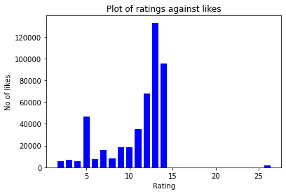

> The chart above suggests that the rating impacts on the numner of likes for each dog, however, more data and futher analysis would be required in order to present this as fact

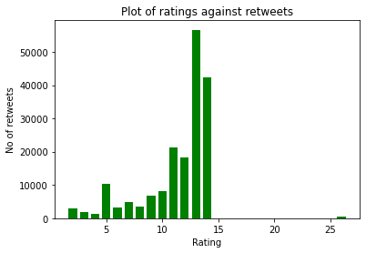

> The chart above suggests that the rating impacts on the number of retweets for each dog, however, more data and futher analysis would be required in order to present this as fact

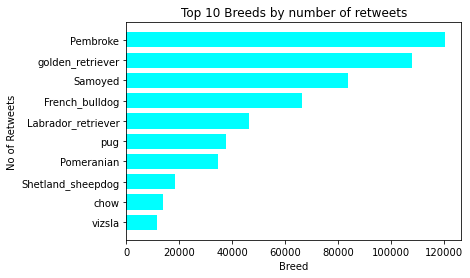

> The chart above shows the top 10 breeds that drew the most retweets

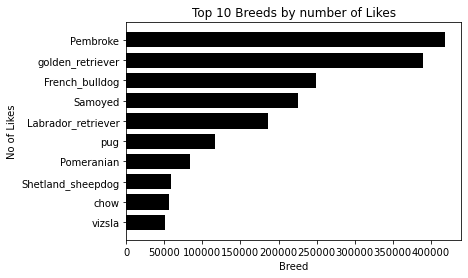

> The chart above shows the top 10 breeds that drew the most likes

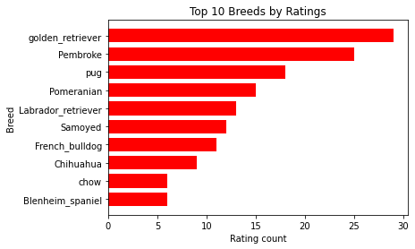

> The chart above shows the top 10 breeds that drew the hightes count of ratings

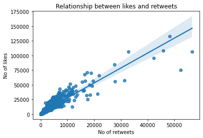

> The chart above shows the strong positive correlation betweeen the number of likes and the number of retweets. In other words, it suggests that as the number of likes for a dog increases, the number of retweets also tend to increase an vice versa